# Minneapolis Public Ash Street Tree Management by Neighborhood

[figure not shown]

[figure not shown]

[figure not shown]

### Public ash trees monitored by Minneapolis Parks and Recreation Board (MPRB) through 2019

[interactive chart not shown]

### **Deferments**: Removal of a public ash tree can sometimes be put on hold (often resulting in a tree being referred to as “blacked out”) usually if nearby homeowners plan to treat the tree or if they requested the city wait until signs the tree was infested with EAB

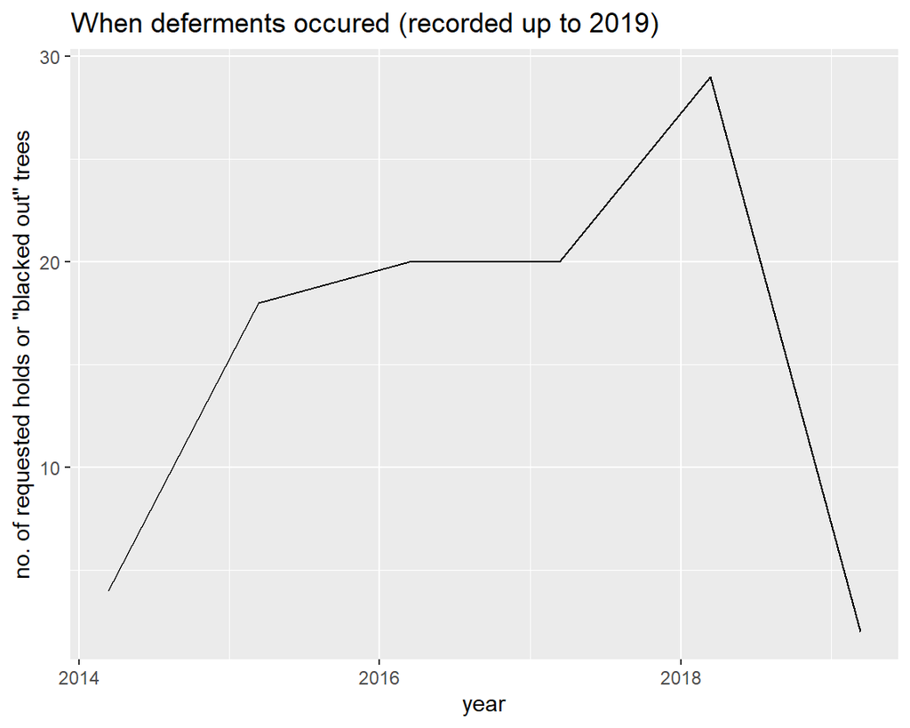

### Top ten neighborhoods where deferral of public ash tree removal was recorded

1 St. Anthony West  
2 Nicollet Island - East Bank  
3 Bryn - Mawr  
4 Audubon Park  
5 Linden Hills  
6 St. Anthony East  
7 East Bde Maka Ska  
8 Marshall Terrace  
9 Waite Park  
10 East Isles

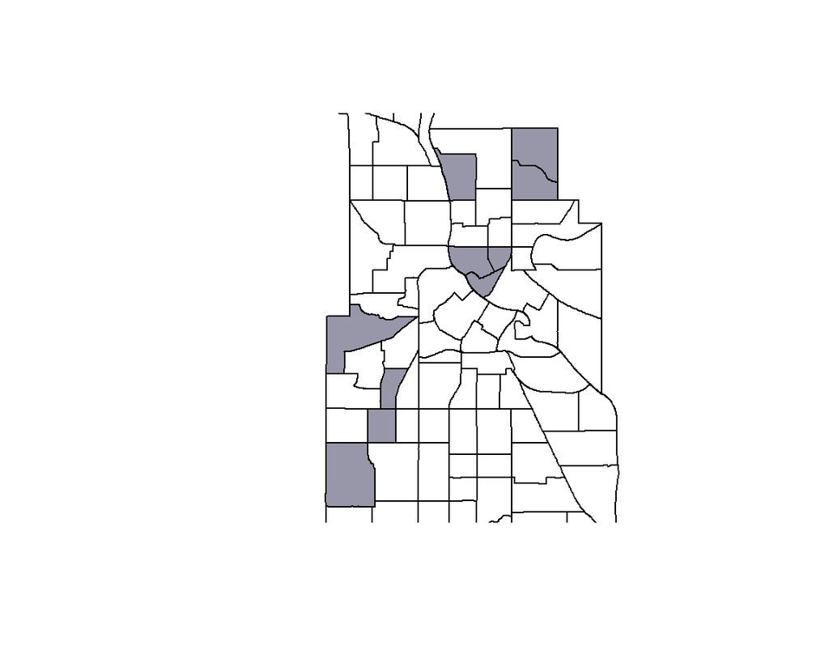

### **Treatments**: Homeowners can pay to treat private and public ash trees if there is enough time and adequate information on options

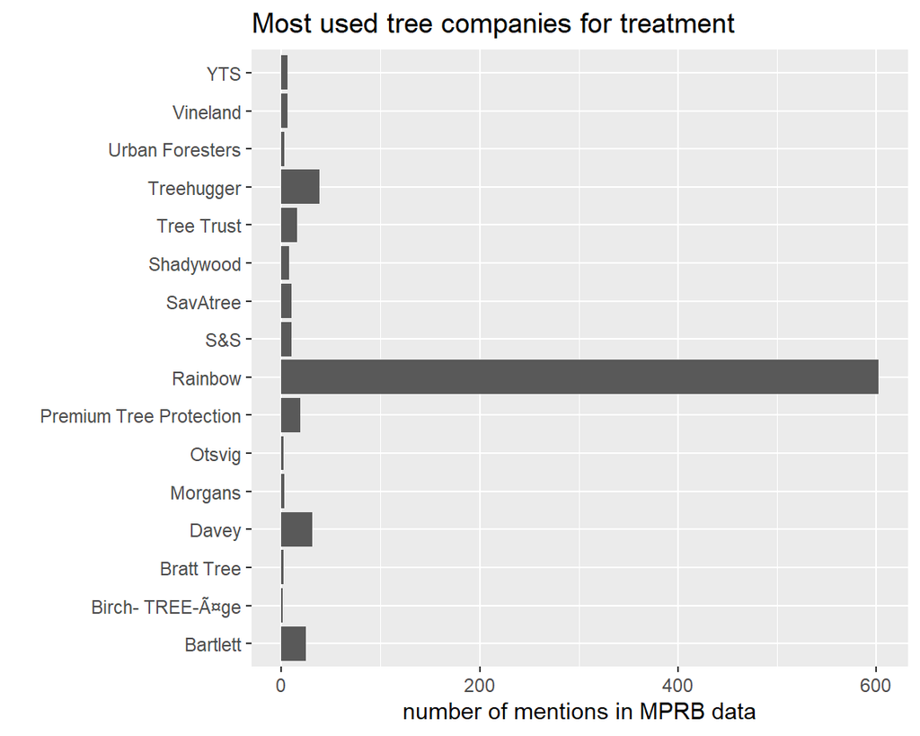

### **Removals**: A complete dataset for public ash trees removed could not be obtained yet, however many public ash trees that existed in the MPRB database obtained by Metro Blooms in 2019 were no longer in the dataset when it was obtained by the MSP LTER in 2021. Many areas with surviving ash trees coincided with treatments, however it is unclear whether these remaining trees are in good health or will eventually be removed. Green dots below represent trees that were present in 2019, but not 2021 while blue dots represent trees remaining in 2021.

[interactive chart not shown]